# PA1_template

Mariano Viola

9/22/2020

1. Load and pre-process the data

```r
if (!file.exists("activity.csv") ) {
        unzip("activity.zip")
}
raw_data <- read.csv("activity.csv", header = TRUE)
main_data <- na.omit(raw_data)
```

2. What is mean total number of steps taken per day?

#Calculate total number of steps per day as data frame with 2 columns - day and sum.

```r
steps_per_day <- aggregate(main_data$steps, by = list(Steps.Date = main_data$date), FUN = "sum")
```

#Make a histogram “Rplot 1” with the frequency of total numbers

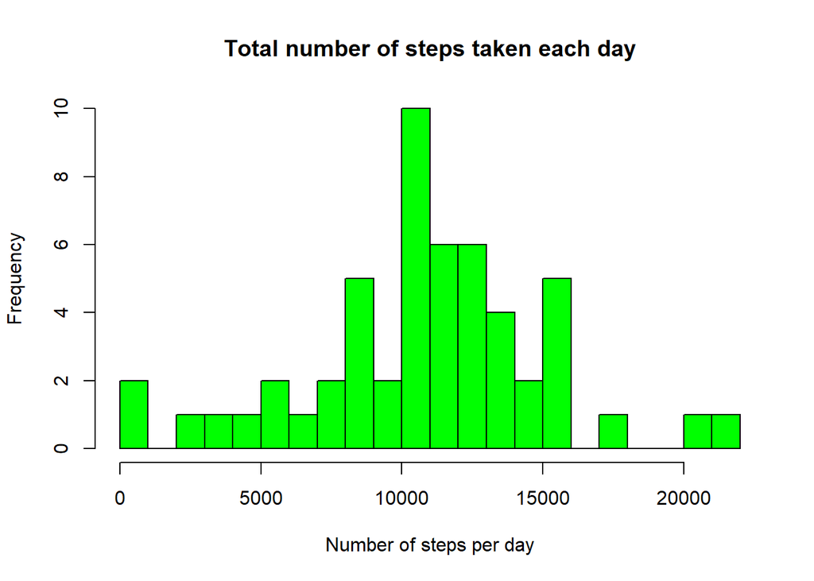

```r
hist(steps_per_day$x, col = "green",
     breaks = 20,
     main = "Total number of steps taken each day",
     xlab = "Number of steps per day")
```

#Calculate the mean and median of the total number of steps

```r
mean_steps <- mean(steps_per_day[,2])
print (mean_steps)
```

```
## [1] 10766.19
```

```r
median_steps <- median(steps_per_day[,2])
print (median_steps)
```

```
## [1] 10765
```

The mean number of steps is 10,766.2 and the median number of steps is 10,765.

3. What is the average daily activity pattern?

#Plot the number of steps taken averaged across all days along 5-min. intervals - “Rplot2”

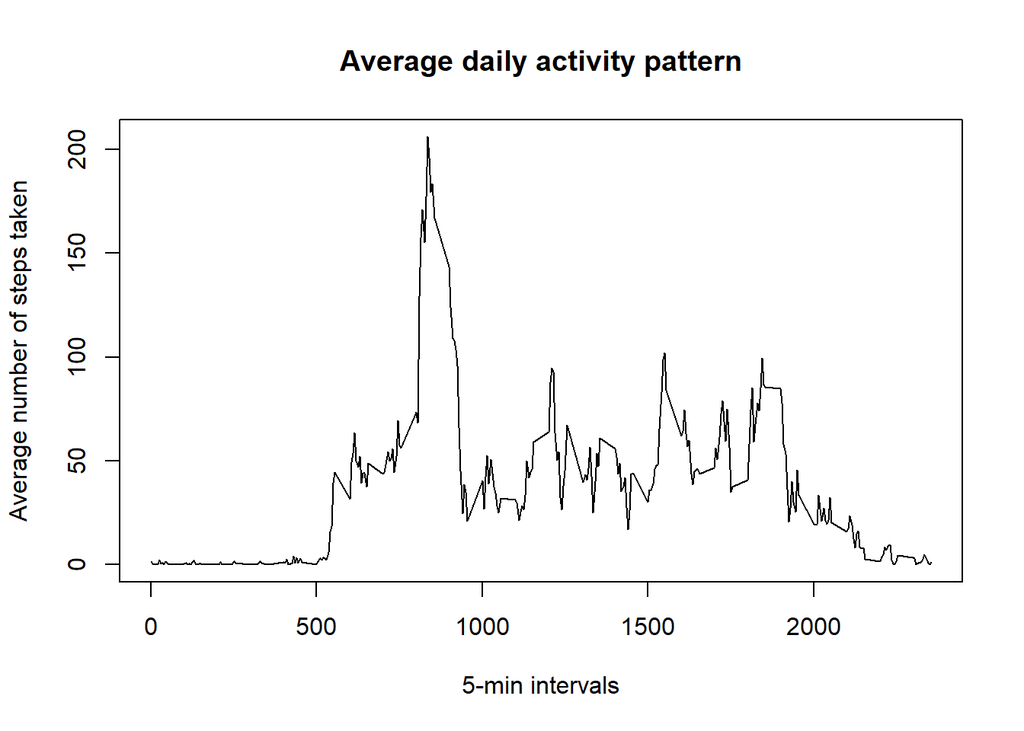

```r
average_day <- aggregate(main_data$steps,
                          by = list(Interval = main_data$interval),
                          FUN = "mean")

plot(average_day$Interval, average_day$x, type = "l",
     main = "Average daily activity pattern",
     ylab = "Average number of steps taken",
     xlab = "5-min intervals")
```

#Define the interval with the maximum number of steps

```r
interval_row <- which.max(average_day$x)
max_interval <- average_day[interval_row,1]
print (max_interval)
```

```
## [1] 835
```

The 5-min. interval of 835 has the maximum number of steps.

4. Imputing missing values

#Calculate the total number of NA values in the dataset

```r
NA_number <- length(which(is.na(raw_data$steps)))
print (NA_number)
```

```
## [1] 2304
```

#Use ‘impute’ function in Hmisc package to fill in NA values. Create a new #dataset with the missing values filled in.

```r
library(Hmisc)
raw_data_filled <- raw_data
raw_data_filled$steps <- impute(raw_data$steps, fun=mean)
```

#Make histogram with new frequencies of total number of steps taken after filling in NA values - “Rplot3”

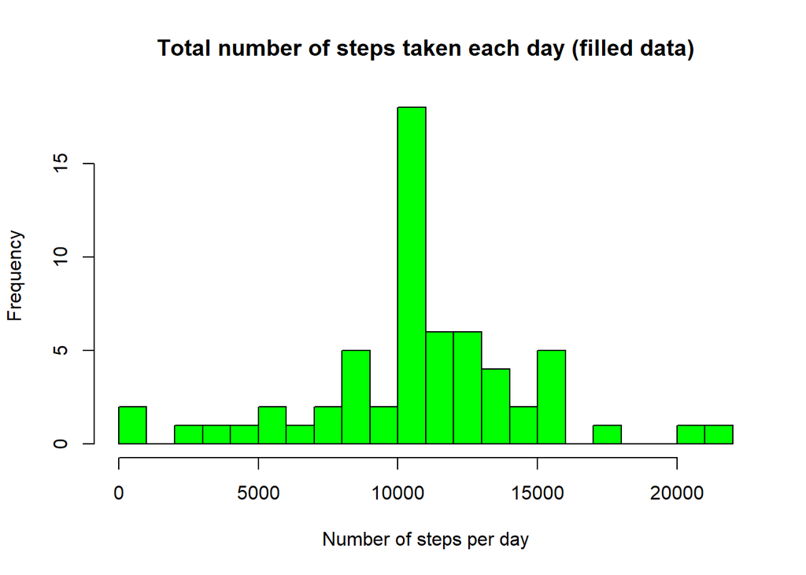

```r
steps_per_day_noNA <- aggregate(raw_data_filled$steps,
                                by = list(Steps.Date = raw_data_filled$date),
                                FUN = "sum")

hist(steps_per_day_noNA$x, col = "green",
     breaks = 20,
     main = "Total number of steps taken each day (filled data)",
     xlab = "Number of steps per day")
```

#Calculate the new mean and median of the total number of steps after imputing missing values

```r
mean_steps_noNA <- mean(steps_per_day_noNA[,2])
print (mean_steps_noNA)
```

```
## [1] 10766.19
```

```r
median_steps_noNA <- median(steps_per_day_noNA[,2])
print (median_steps_noNA)
```

```
## [1] 10766.19
```

5. Are there differences in activity patterns between weekdays and weekends?

#Create a new variable in the dataset that tells whether a given date is a weekday or a weekend day

```r
raw_data_filled$date <- as.Date(raw_data_filled$date)
raw_data_filled$weekday <- weekdays(raw_data_filled$date)
raw_data_filled$day_type <- ifelse(raw_data_filled$weekday=="Saturday" |
                                           raw_data_filled$weekday=="Sunday","Weekend","Weekday")
raw_data_filled$day_type <- factor(raw_data_filled$day_type)
```

#Plot the number of steps for all 5-min. intervals, averaged across weekdays and weekends separately #See Rplot4

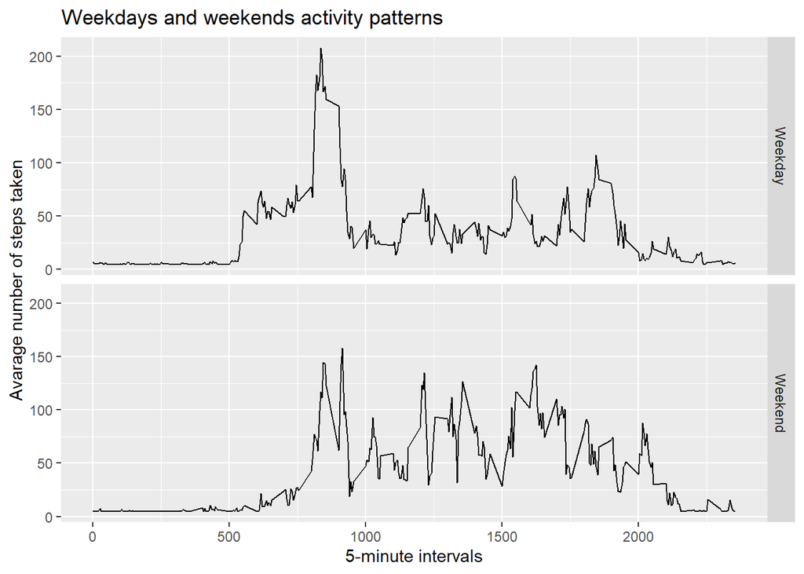

```r
day_types_data <- aggregate(steps ~ interval + day_type, data=raw_data_filled, mean)

library(ggplot2)
ggplot(day_types_data, aes(interval, steps)) +
        geom_line() +
        facet_grid(day_type ~ .) +
        xlab("5-minute intervals") +
        ylab("Avarage number of steps taken") +
        ggtitle("Weekdays and weekends activity patterns")
```

The number of steps on weekend tend to be higher on average during the day, but the peak in the morning is higher on weekdays.